# Tugas 5 Praktikum MPDW

David Fauzan Akmal

2024-09-22

### Memuat Library

```r
library(readxl)
```

```r
library(ggplot2)
library(tsibble)
library(tseries)
library(MASS)
```

## Data Lengkap Periode 1-100

### Impor Data

```r
data.pm <- read_excel("C://Users/USER/Downloads/Database MPDW.xlsx", sheet=1)
data.pm <-data.pm[1:100,1:2]
data.pm <- data.frame(
  Tanggal = data.pm$Tanggal,
  SS = data.pm$SS
)
```

### Menambahkan 0.01 ke data pada kolom SS karena terdapat amatan bernilai 0

```r
data.pm$SS <- data.pm$SS + 0.01
data.pm
```

```
##        Tanggal   SS
## 1   2023-01-01 0.01
## 2   2023-01-02 0.01
## 3   2023-01-03 0.61
## 4   2023-01-04 0.01
## 5   2023-01-05 0.41
## 6   2023-01-06 2.81
## 7   2023-01-07 6.41
## 8   2023-01-08 5.01
## 9   2023-01-09 3.71
## 10  2023-01-10 2.71
## 11  2023-01-11 5.01
## 12  2023-01-12 4.71
## 13  2023-01-13 2.51
## 14  2023-01-14 3.11
```

[output cut: 86 more lines]

### Mengubah Data agar Terbaca sebagai Data Deret Waktu

```r
datapm.ts <- ts(data.pm$SS)
```

### Membuat Plot Data Deret Waktu

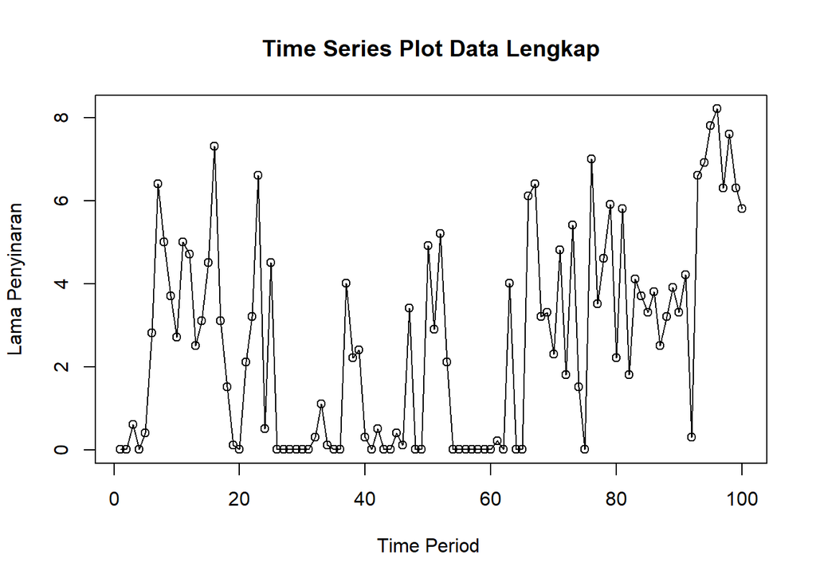

```r
ts.plot(datapm.ts, xlab="Time Period ", ylab="Lama Penyinaran",
        main = "Time Series Plot Data Lengkap")
points(datapm.ts)
```

```r
mean(datapm.ts)
```

```
## [1] 2.588
```

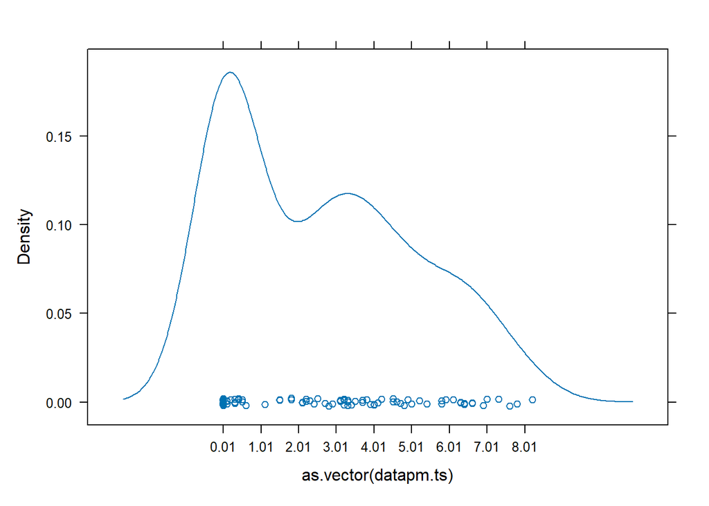

```r
lattice::densityplot(as.vector(datapm.ts),
            scales = list(x = list(at = seq(min(as.vector(datapm.ts)),
                                            max(as.vector(datapm.ts)),
                                            by = 1))))
```

Plot deret waktu di atas menunjukkan bahwa data **tidak** stasioner dalam rataan, ditandai dengan data **tidak** menyebar di sekitar nilai tengahnya (2.588) dan **tidak** stasioner dalam ragam, ditandai dengan lebar pita yang berbeda. Agar lebih pasti, dapat dibuat plot ACF, uji ADF, serta plot Box-Cox.

### Plot ACF

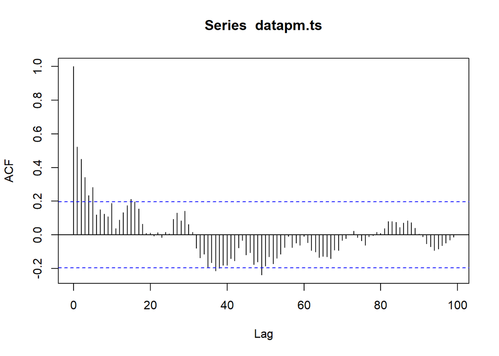

```r
acf(datapm.ts, lag.max = 100)
```

Berdasarkan plot ACF, terlihat bahwa plot ACF pada data tersebut cenderung *tails off* dan menunjukkan sedikit pola gelombang sinus yang tidak sempurna.

### Melakukan Uji ADF agar Lebih Yakin terhadap Kestasioneran Data

```r
adf.test(datapm.ts)
```

```
##
##  Augmented Dickey-Fuller Test
##
## data:  datapm.ts
## Dickey-Fuller = -2.3729, Lag order = 4, p-value = 0.4221
## alternative hypothesis: stationary
```

$H_0$ : Data tidak stasioner dalam rataan

$H_1$ : Data stasioner dalam rataan

Berdasarkan uji ADF tersebut, didapat *p-value* sebesar 0.4221 yang lebih besar dari taraf nyata 5% sehingga **gagal** tolak $H_0$ dan menandakan bahwa data **tidak** stasioner dalam rataan. Hal ini sesuai dengan hasil eksplorasi menggunakan plot time series.

### Plot Box-Cox untuk Mengetahui Kestasioneran Ragam Data

```r
index <- seq(1:100)
bc = boxcox(datapm.ts~index, lambda = seq(0,2,by=0.01))
```

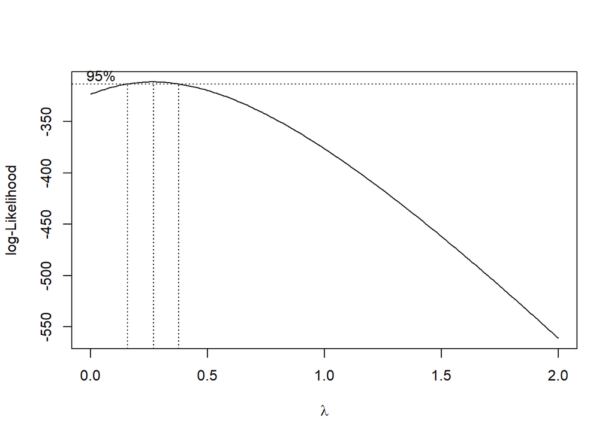

```r
#Nilai Rounded Lambda
lambda1 <- bc$x[which.max(bc$y)]
lambda1
```

```
## [1] 0.27
```

```r
#SK
bc$x[bc$y > max(bc$y) - 1/2 * qchisq(.95,1)]
```

```
##  [1] 0.16 0.17 0.18 0.19 0.20 0.21 0.22 0.23 0.24 0.25 0.26 0.27 0.28 0.29 0.30
## [16] 0.31 0.32 0.33 0.34 0.35 0.36 0.37
```

Gambar di atas menunjukkan nilai *rounded value* ($\lambda$) optimum sebesar **0.27** dan pada selang kepercayaan 95% nilai memiliki batas bawah **0.16** dan batas atas **0.37**. Selang tersebut **tidak** memuat nilai satu sehingga dapat dikatakan bahwa data **tidak** stasioner dalam ragam.

## Partisi Data Periode 1-50 (First Half/Setengah Pertama)

### Impor Data (Ket: fh = first half)

```r
datapm.fh <- read_excel("C://Users/USER/Downloads/Database MPDW.xlsx", sheet=1)
datapm.fh <-datapm.fh[1:50,1:2]
datapm.fh <- data.frame(
  Tanggal = datapm.fh$Tanggal,
  SS = datapm.fh$SS
)
```

### Menambahkan 0.01 ke data pada kolom SS karena terdapat amatan bernilai 0

```r
datapm.fh$SS <- datapm.fh$SS + 0.01
datapm.fh
```

```
##       Tanggal   SS
## 1  2023-01-01 0.01
## 2  2023-01-02 0.01
## 3  2023-01-03 0.61
## 4  2023-01-04 0.01
## 5  2023-01-05 0.41
## 6  2023-01-06 2.81
## 7  2023-01-07 6.41
## 8  2023-01-08 5.01
## 9  2023-01-09 3.71
## 10 2023-01-10 2.71
## 11 2023-01-11 5.01
## 12 2023-01-12 4.71
## 13 2023-01-13 2.51
## 14 2023-01-14 3.11
```

[output cut: 36 more lines]

### Mengubah Data agar Terbaca sebagai Data Deret Waktu

```r
datafh.ts <- ts(datapm.fh$SS)
```

### Membuat Plot Data Deret Waktu

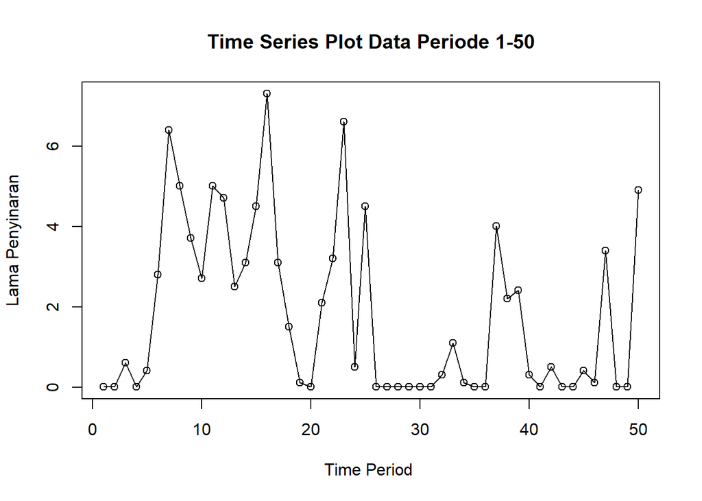

```r
ts.plot(datafh.ts, xlab="Time Period ", ylab="Lama Penyinaran",
        main = "Time Series Plot Data Periode 1-50")
points(datafh.ts)
```

```r
mean(datafh.ts)
```

```
## [1] 1.81
```

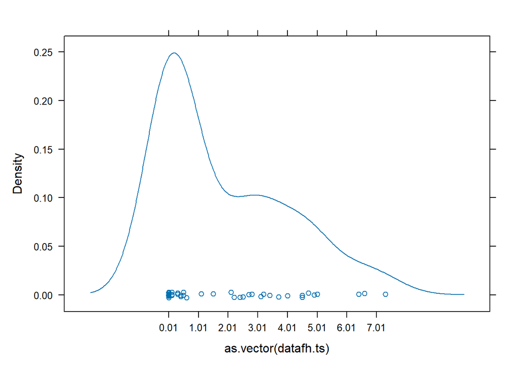

```r
lattice::densityplot(as.vector(datafh.ts),
            scales = list(x = list(at = seq(min(as.vector(datafh.ts)),
                                            max(as.vector(datafh.ts)),
                                            by = 1))))
```

Plot deret waktu di atas menunjukkan bahwa data **tidak** stasioner dalam rataan, ditandai dengan data **tidak** menyebar di sekitar nilai tengahnya (1.81) dan **tidak** stasioner dalam ragam, ditandai dengan lebar pita yang berbeda.

### Plot ACF

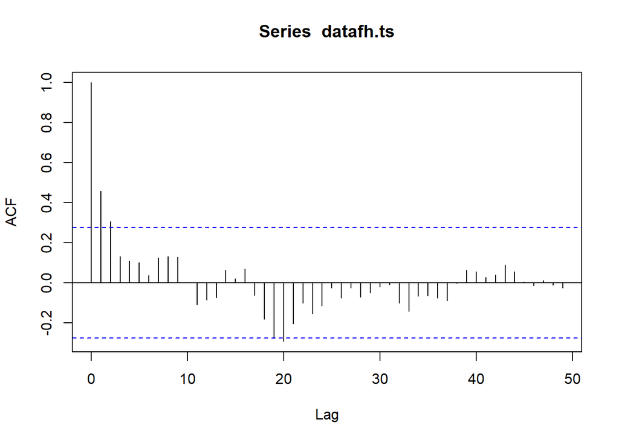

```r
acf(datafh.ts, lag.max = 50)
```

Berdasarkan plot ACF, terlihat bahwa plot ACF pada data tersebut cenderung *tails off* dan sedikit menyerupai gelombang sinus namun tidak sempurna.

### Melakukan Uji ADF agar Lebih Yakin terhadap Kestasioneran Data

```r
adf.test(datafh.ts)
```

```
##
##  Augmented Dickey-Fuller Test
##
## data:  datafh.ts
## Dickey-Fuller = -3.3433, Lag order = 3, p-value = 0.07498
## alternative hypothesis: stationary
```

$H_0$ : Data tidak stasioner dalam rataan

$H_1$ : Data stasioner dalam rataan

Berdasarkan uji ADF tersebut, didapat *p-value* sebesar 0.07498 yang lebih besar dari taraf nyata 5% sehingga **gagal** tolak $H_0$ dan menandakan bahwa data **tidak** stasioner dalam rataan. Hal ini sesuai dengan hasil eksplorasi menggunakan plot time series.

### Plot Box-Cox untuk Mengetahui Kestasioneran Ragam Data

```r
index <- seq(1:50)
bc = boxcox(datafh.ts~index, lambda = seq(0,2,by=0.01))
```

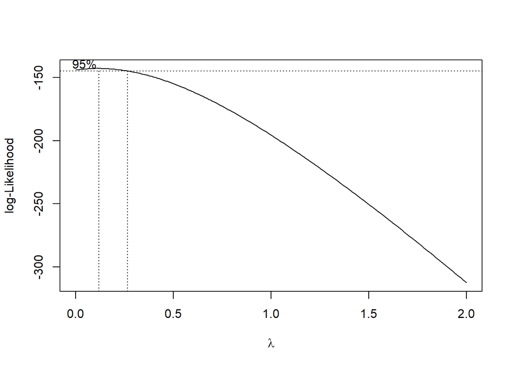

```r
#Nilai Rounded Lambda
lambda2 <- bc$x[which.max(bc$y)]
lambda2
```

```
## [1] 0.12
```

```r
#SK
bc$x[bc$y > max(bc$y) - 1/2 * qchisq(.95,1)]
```

```
##  [1] 0.00 0.01 0.02 0.03 0.04 0.05 0.06 0.07 0.08 0.09 0.10 0.11 0.12 0.13 0.14
## [16] 0.15 0.16 0.17 0.18 0.19 0.20 0.21 0.22 0.23 0.24 0.25 0.26
```

Gambar di atas menunjukkan nilai *rounded value* ($\lambda$) optimum sebesar **0.12** dan pada selang kepercayaan 95% nilai memiliki batas bawah **0.00** dan batas atas **0.26**. Selang tersebut **tidak** memuat nilai satu sehingga dapat dikatakan bahwa data **tidak** stasioner dalam ragam.

## Partisi Data Periode 51-100 (Second Half/Setengah Kedua)

### Impor Data (Ket: sh = second half)

```r
datapm.sh <- read_excel("C://Users/USER/Downloads/Database MPDW.xlsx", sheet=1)
datapm.sh <-datapm.sh[51:100,1:2]
datapm.sh <- data.frame(
  Tanggal = datapm.sh$Tanggal,
  SS = datapm.sh$SS
)
```

### Menambahkan 0.01 ke data pada kolom SS karena terdapat amatan bernilai 0

```r
datapm.sh$SS <- datapm.sh$SS + 0.01
datapm.sh
```

```
##       Tanggal   SS
## 1  2023-02-20 2.91
## 2  2023-02-21 5.21
## 3  2023-02-22 2.11
## 4  2023-02-23 0.01
## 5  2023-02-24 0.01
## 6  2023-02-25 0.01
## 7  2023-02-26 0.01
## 8  2023-02-27 0.01
## 9  2023-02-28 0.01
## 10 2023-03-01 0.01
## 11 2023-03-02 0.21
## 12 2023-03-03 0.01
## 13 2023-03-04 4.01
## 14 2023-03-05 0.01
```

[output cut: 36 more lines]

### Mengubah Data agar Terbaca sebagai Data Deret Waktu

```r
datash.ts <- ts(datapm.sh$SS)
```

### Membuat Plot Data Deret Waktu

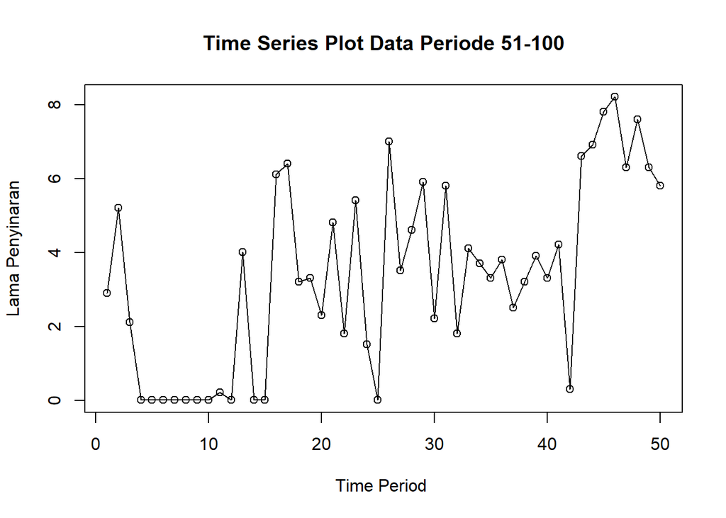

```r
ts.plot(datash.ts, xlab="Time Period ", ylab="Lama Penyinaran",
        main = "Time Series Plot Data Periode 51-100")
points(datash.ts)
```

```r
mean(datash.ts)
```

```
## [1] 3.366
```

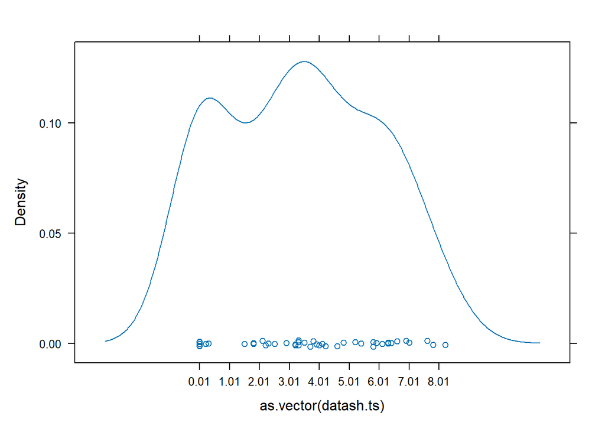

```r
lattice::densityplot(as.vector(datash.ts),
            scales = list(x = list(at = seq(min(as.vector(datash.ts)),
                                            max(as.vector(datash.ts)),
                                            by = 1))))
```

Plot deret waktu di atas menunjukkan bahwa data **tidak** stasioner dalam rataan, ditandai dengan data **tidak** menyebar di sekitar nilai tengahnya (3.366) dan **tidak** stasioner dalam ragam, ditandai dengan lebar pita yang berbeda.

### Plot ACF

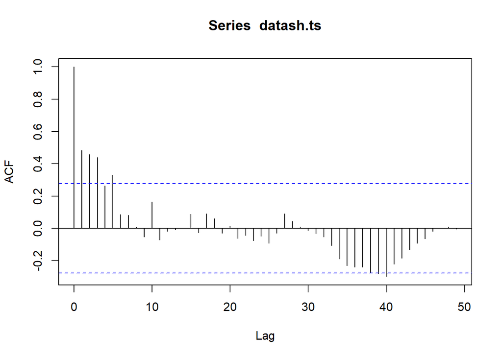

```r
acf(datash.ts, lag.max = 50)
```

Berdasarkan plot ACF, terlihat bahwa plot ACF pada data tersebut cenderung *tails off* dan sedikit menyerupai gelombang sinus namun tidak sempurna.

### Melakukan Uji ADF agar Lebih Yakin terhadap Kestasioneran Data

```r
adf.test(datash.ts)
```

```
##
##  Augmented Dickey-Fuller Test
##
## data:  datash.ts
## Dickey-Fuller = -3.17, Lag order = 3, p-value = 0.105
## alternative hypothesis: stationary
```

$H_0$ : Data tidak stasioner dalam rataan

$H_1$ : Data stasioner dalam rataan

Berdasarkan uji ADF tersebut, didapat *p-value* sebesar 0.105 yang lebih besar dari taraf nyata 5% sehingga **gagal** tolak $H_0$ dan menandakan bahwa data **tidak** stasioner dalam rataan. Hal ini sesuai dengan hasil eksplorasi menggunakan plot time series.

### Plot Box-Cox untuk Mengetahui Kestasioneran Ragam Data

```r
index <- seq(1:50)
bc = boxcox(datash.ts~index, lambda = seq(0,4,by=0.01))
```

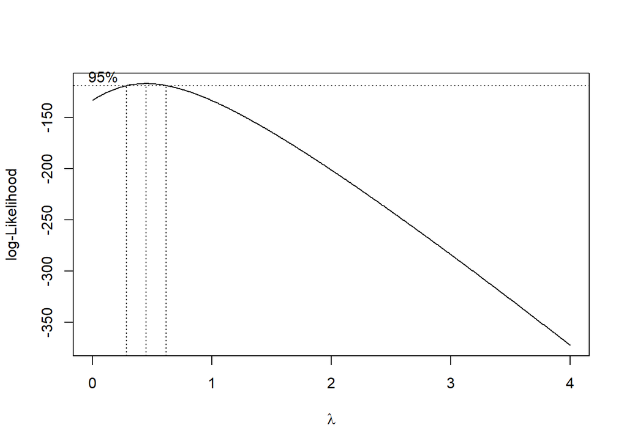

```r
#Nilai Rounded Lambda
lambda3 <- bc$x[which.max(bc$y)]
lambda3
```

```
## [1] 0.45
```

```r
#SK
bc$x[bc$y > max(bc$y) - 1/2 * qchisq(.95,1)]
```

```
##  [1] 0.29 0.30 0.31 0.32 0.33 0.34 0.35 0.36 0.37 0.38 0.39 0.40 0.41 0.42 0.43
## [16] 0.44 0.45 0.46 0.47 0.48 0.49 0.50 0.51 0.52 0.53 0.54 0.55 0.56 0.57 0.58
## [31] 0.59 0.60 0.61
```

Gambar di atas menunjukkan nilai *rounded value* ($\lambda$) optimum sebesar **0.45** dan pada selang kepercayaan 95% nilai memiliki batas bawah **0.29** dan batas atas **0.61**. Selang tersebut **tidak** memuat nilai satu sehingga dapat dikatakan bahwa data **tidak** stasioner dalam ragam.